# Final Project

Using the prune command (prune(rpart.fit, cp = )) to prune traffic.train_prune

```r
traffic.prune_1se <- prune(traffic.train_prune, cp = cp.1se)
print(traffic.prune_1se)
```

```
## n= 2400
##
## node), split, n, loss, yval, (yprob)
##       * denotes terminal node
##
##  1) root 2400 243 0 (0.89875000 0.10125000)
##    2) src_bytes< 18395.5 2323 168 0 (0.92767972 0.07232028)
##      4) service=http,smtp,domain_u,other 2026  56 0 (0.97235933 0.02764067)
##        8) is_guest_login=0 1990  29 0 (0.98542714 0.01457286) *
##        9) is_guest_login=1 36   9 1 (0.25000000 0.75000000) *
##      5) service=private,ftp_data 297 112 0 (0.62289562 0.37710438)
##       10) src_bytes>=14 264  80 0 (0.69696970 0.30303030) *
##       11) src_bytes< 14 33   1 1 (0.03030303 0.96969697) *
##    3) src_bytes>=18395.5 77   2 1 (0.02597403 0.97402597) *
```

```r
prune.test.prob <- predict(traffic.prune_1se, newdata = traffic.test, type = "prob")[,"1"]


score.factor_prune <- factor(as.numeric(prune.test.prob >= .5), levels = c("0", "1"))
confusion.mat_prune <- table(score.factor_prune, as.factor(traffic.test$is_intrusion), dnn = list("predicted", "observed"))

confusion.mat_prune
```

```
##          observed
## predicted   0   1
##         0 539  28
##         1   4  29
```

```r
mean((prune.test.prob -
        as.numeric(as.character(traffic.test$is_intrusion)))^2)
```

```
## [1] 0.04384404
```

The MSE value for the pruned model fitted above is 0.04384404.

```r
y_prune_test = as.numeric(as.character(traffic.test$is_intrusion))


misclass_prune <- c()
sensitivity_prune <- c()

cutoff_prune <- (1:15)/10

for(cutoff_prune_i in cutoff_prune) {
  score.factor_prune_vec <- factor(as.numeric(prune.test.prob >= cutoff_prune_i), levels = c("0", "1"))
  confusion.mat_prune_vec <- table(score.factor_prune_vec, as.factor(y_prune_test), dnn = list("predicted", "observed"))

  miss_prune <- mean(as.factor(y_prune_test) != score.factor_prune_vec)
  misclass_prune <- append(misclass_prune, miss_prune)
  tab_prune <- table(score.factor_prune_vec, as.factor(y_prune_test))

  sens_prune <- (tab_prune[2,2]/(tab_prune[2,2] + tab_prune[1,2]))
  sensitivity_prune <- append(sensitivity_prune, sens_prune)
}

sensitivity_prune
```

```
##  [1] 0.8596491 0.8596491 0.8596491 0.5087719 0.5087719 0.5087719 0.5087719
##  [8] 0.4035088 0.4035088 0.0000000 0.0000000 0.0000000 0.0000000 0.0000000
## [15] 0.0000000
```

```r
misclass_prune
```

```
##  [1] 0.12333333 0.12333333 0.12333333 0.05333333 0.05333333 0.05333333
##  [7] 0.05333333 0.05833333 0.05833333 0.09500000 0.09500000 0.09500000
## [13] 0.09500000 0.09500000 0.09500000
```

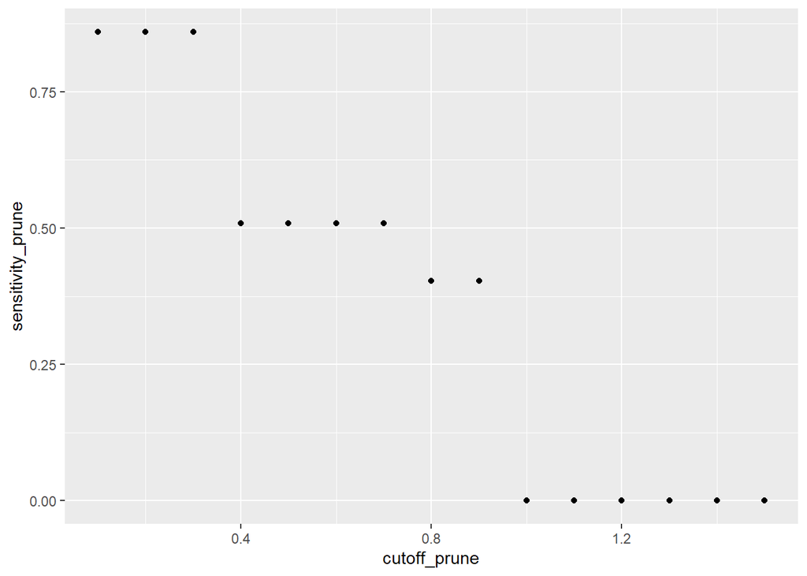

```r
qplot(cutoff_prune, sensitivity_prune)
```

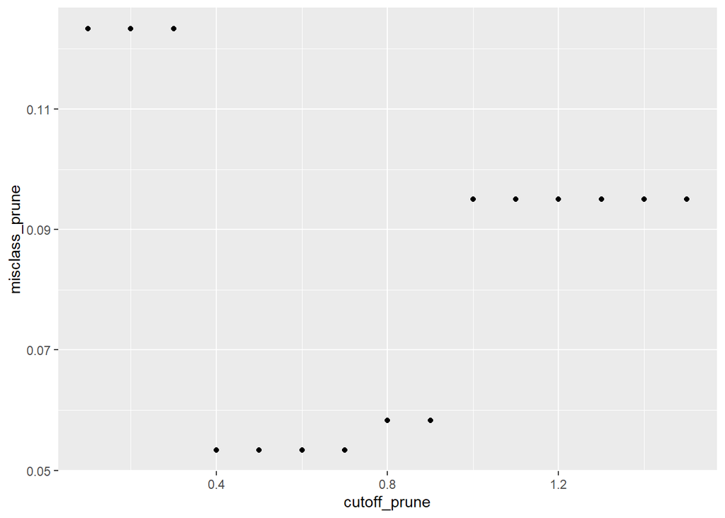

```r
qplot(cutoff_prune, misclass_prune)
```

Final model evaluation:

Testing: Find the error rates for all of the models on traffic.test data Compare with some graphs Sensitivity: Proportion of cases predicted as 1 among all cases of intrusion. Negative predictive value: probability that if is_intrusion = 0, there actually is not an intrusion. False negative is more expensive

```r
metrics <- function(table) {
  true.neg = table["0", "0"]
  true.pos = table["1", "1"]
  false.neg = table["0", "1"]
  false.pos = table["1", "0"]

  accuracy = (true.neg + true.pos)/(true.neg + true.pos + false.neg + false.pos)
  sensitivity = true.pos / (true.pos + false.neg)
  npv = true.neg / (true.neg + false.neg)
  metric.names <- c("accuracy", "sensitivity", "npv")

  value <- c(accuracy, sensitivity, npv)
  df<- data.frame(value)
  row.names(df) <- metric.names

  return(df)
}
```

Plot ROC curve with these predictions

Full logistic regression model:

```r
glm.testprob <- predict(glm.allfit, traffic.test, type="response")

glm.roc <- roc(traffic.test$is_intrusion, glm.testprob)
```

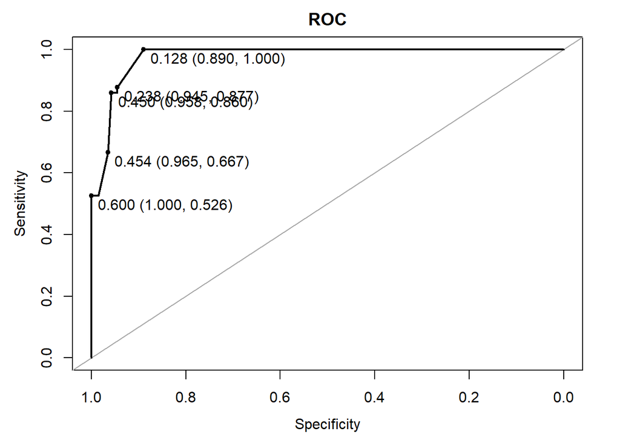

```r
plot.roc(glm.roc, print.thres = "local maximas", percent=TRUE, main="ROC", add=FALSE, asp=NA)
```

The logistic regression model has perfect sensitivity for any threshold level less than 0.128. At 0.128, the specificity is still very high. Note: exact value may be different based on test and training data randomization.

```r
glm.testpred <- rep(0, nrow(traffic.test))
glm.testpred[glm.testprob>.128] = 1
glm.mat <- table(glm.testpred, traffic.test$is_intrusion)
glm.mat
```

```
##
## glm.testpred   0   1
##            0 483   0
##            1  60  57
```

```r
glm.metrics <- metrics(glm.mat)
glm.metrics
```

```
##             value
## accuracy      0.9
## sensitivity   1.0
## npv           1.0
```

```r
miss_glm <- mean(traffic.test$is_intrusion != glm.testpred)
```

Best subset selection with 8 variables

```r
glm.besttestprob <- predict(glm.best, traffic.test, type="response")
glm.bestroc <- roc(traffic.test$is_intrusion, glm.besttestprob)
```

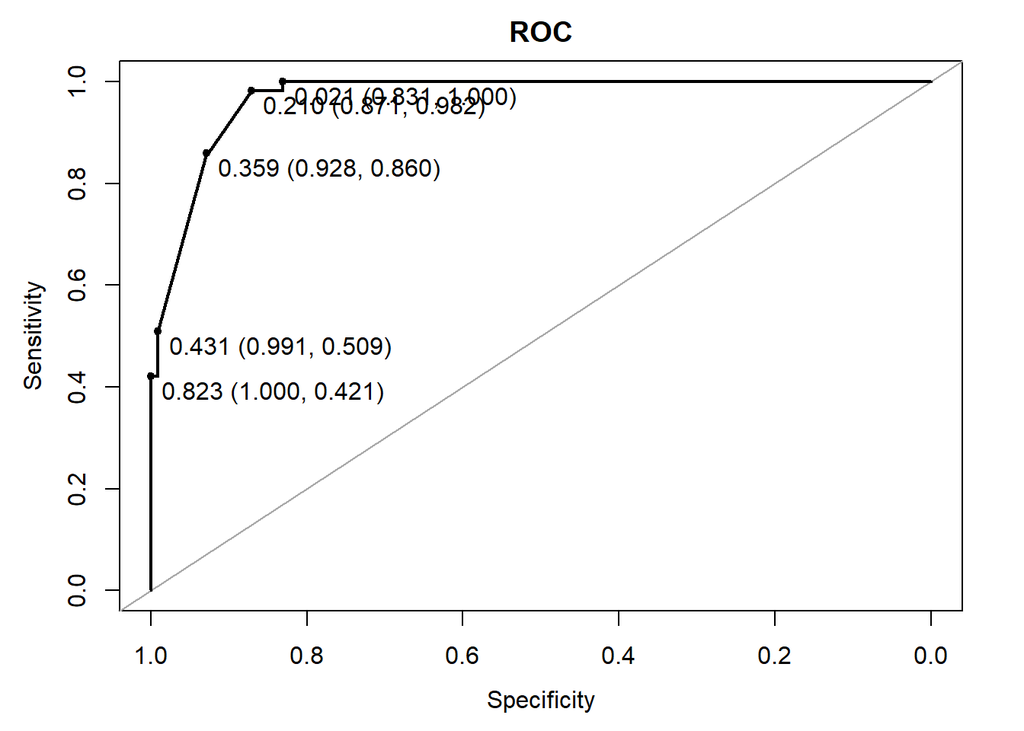

```r
plot.roc(glm.bestroc, print.thres = "local maximas", percent=TRUE, main="ROC", add=FALSE, asp=NA)
```

```r
glm.besttestpred <- rep(0, nrow(traffic.test))
glm.besttestpred[glm.besttestprob>.21] = 1
bestglm.mat <- table(glm.besttestpred, traffic.test$is_intrusion)
bestglm.mat
```

```
##
## glm.besttestpred   0   1
##                0 473   1
##                1  70  56
```

```r
bestglm.metrics <- metrics(bestglm.mat)
bestglm.metrics
```

```
##                 value
## accuracy    0.8816667
## sensitivity 0.9824561
## npv         0.9978903
```

```r
miss_bestglm <- mean(traffic.test$is_intrusion != glm.besttestpred)
```

ROC for lasso

```r
lasso.prob <- predict(intrusion_lasso, s=bestlam, newx = x_lasso_test)
lasso.roc <- roc(traffic.test$is_intrusion, lasso.prob)
```

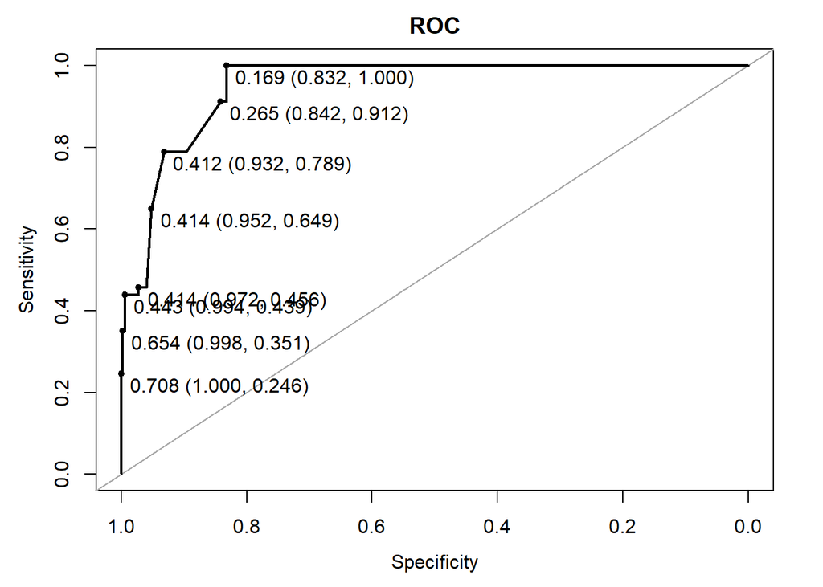

```r
plot.roc(lasso.roc, print.thres = "local maximas", percent=TRUE,
         main="ROC", add=FALSE, asp=NA)
```

The lasso achieves a perfect sensitivity and a high specificity at a cutoff of 0.169. This will be the cutoff used.

```r
lasso.pred <- rep(0, nrow(traffic.test))
lasso.pred[lasso.prob > .17] = 1
lasso.mat <- table(lasso.pred, y_lasso_test)
lasso.mat
```

```
##           y_lasso_test
## lasso.pred   0   1
##          0 452   0
##          1  91  57
```

```r
lasso.metrics <- metrics(lasso.mat)
lasso.metrics
```

```
##                 value
## accuracy    0.8483333
## sensitivity 1.0000000
## npv         1.0000000
```

```r
miss_lasso <- mean(traffic.test$is_intrusion != lasso.pred)
```

Find metrics for KNN using the best k value of k = 4

```r
tab_knn <- table(knn.best, scale.traffic.test$is_intrusion)
knn.metrics <- metrics(tab_knn)
knn.metrics
```

```
##                 value
## accuracy    0.9500000
## sensitivity 0.5263158
## npv         0.9523810
```

```r
miss_knn <- mean(traffic.test$is_intrusion != knn.best)
```

```r
rf.prob <- predict(traffic.rf, newdata=traffic.test, type="prob")[,"1"]
rf.roc <- roc(traffic.test$is_intrusion, rf.prob)
```

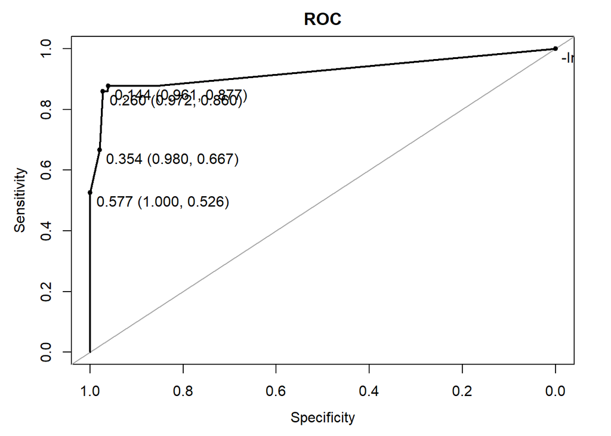

```r
plot.roc(rf.roc, print.thres = "local maximas", percent=TRUE,
         main="ROC", add=FALSE, asp=NA)
```

```r
rf.pred <- rep(0, nrow(traffic.test))
rf.pred[rf.prob > .154] = 1
rf.mat <- table(rf.pred, traffic.test$is_intrusion)
rf.mat
```

```
##
## rf.pred   0   1
##       0 523   8
##       1  20  49
```

```r
rf.metrics <- metrics(rf.mat)
rf.metrics
```

```
##                 value
## accuracy    0.9533333
## sensitivity 0.8596491
## npv         0.9849341
```

```r
miss_rf <- mean(traffic.test$is_intrusion != rf.pred)
```

```r
prune.prob <- predict(traffic.prune_1se, newdata = traffic.test, type = "prob")[,"1"]
prune.roc <- roc(traffic.test$is_intrusion, prune.prob)
```

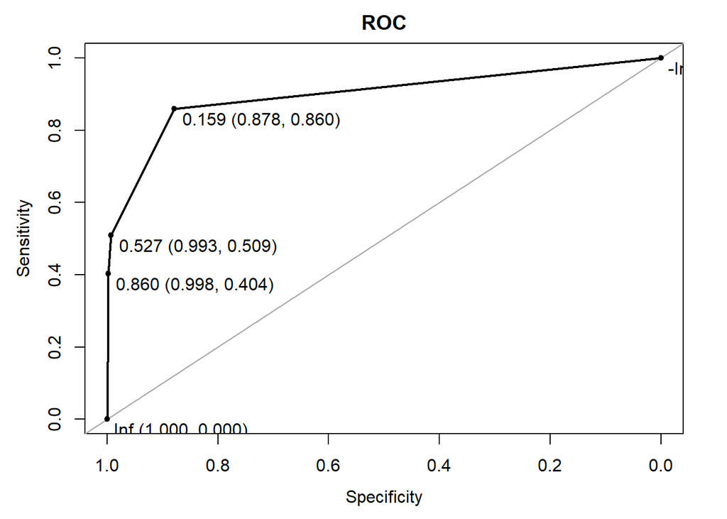

```r
plot.roc(prune.roc, print.thres = "local maximas", percent=TRUE,
         main="ROC", add=FALSE, asp=NA)
```

A cutoff of about 0.16 gives a high sensivity with small tradeoffs to specificity.

```r
prune.pred <- rep(0, nrow(traffic.test))
prune.pred[prune.prob > 0.16] = 1
prune.mat <- table(prune.pred, traffic.test$is_intrusion)
prune.mat
```

```
##
## prune.pred   0   1
##          0 477   8
##          1  66  49
```

```r
prune.metrics <- metrics(prune.mat)
prune.metrics
```

```
##                 value
## accuracy    0.8766667
## sensitivity 0.8596491
## npv         0.9835052
```

```r
miss_prune <- mean(traffic.test$is_intrusion != rf.pred)
miss_prune
```

```
## [1] 0.04666667
```

Plot the Accuracy, sensitivity, npv, and percent misclassified of all models

```r
metrics <- c(glm.metrics, bestglm.metrics, lasso.metrics, knn.metrics, rf.metrics, prune.metrics)
fit.names <- c("Log Reg", "Subset Log Reg", "Lasso", "KNN", "Random Forest", "Pruned Tree")
accuracy <- c()
sensitivity <- c()
npv <- c()
metric.df <- data.frame(matrix(ncol=3, nrow=2))
for(i in metrics) {
  accuracy <- append(accuracy, i[1])
  sensitivity <- append(sensitivity, i[2])
  npv <- append(npv, i[3])
}
misclassified <- 100*c(miss_glm, miss_bestglm, miss_lasso, miss_knn, miss_rf, miss_prune)
metric.df = data.frame(fit.names, accuracy, sensitivity, npv, misclassified)
metric.df
```

```
##        fit.names  accuracy sensitivity       npv misclassified
## 1        Log Reg 0.9000000   1.0000000 1.0000000     10.000000
## 2 Subset Log Reg 0.8816667   0.9824561 0.9978903     11.833333
## 3          Lasso 0.8483333   1.0000000 1.0000000     15.166667
## 4            KNN 0.9500000   0.5263158 0.9523810      5.000000
## 5  Random Forest 0.9533333   0.8596491 0.9849341      4.666667
## 6    Pruned Tree 0.8766667   0.8596491 0.9835052      4.666667
```

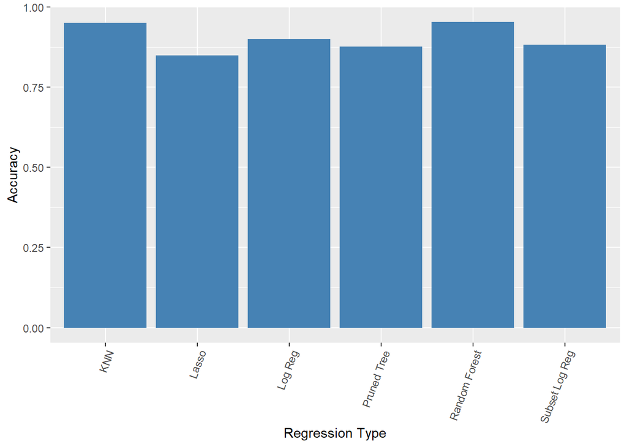

```r
ggplot(data=metric.df, aes(x=fit.names, y=accuracy)) +
  geom_bar(stat="identity", fill="steelblue") +
  theme(axis.text.x = element_text(angle=70, hjust=1)) +
  xlab("Regression Type") +
  ylab("Accuracy")
```

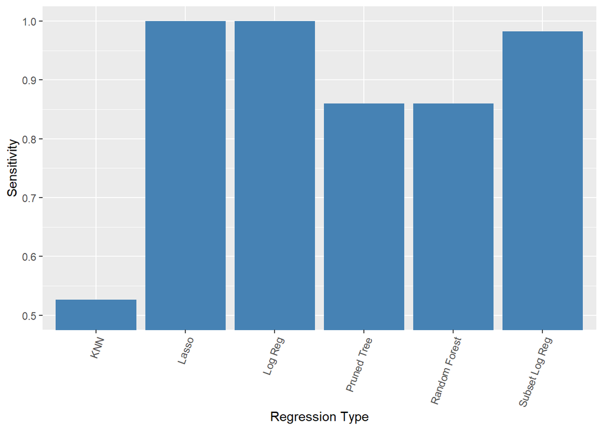

```r
ggplot(data=metric.df, aes(x=fit.names, y=sensitivity)) +
  geom_bar(stat="identity", fill="steelblue") +
  theme(axis.text.x = element_text(angle=70, hjust=1)) +
  xlab("Regression Type") +
  ylab("Sensitivity") +
  coord_cartesian(ylim=c(.5, 1))
```

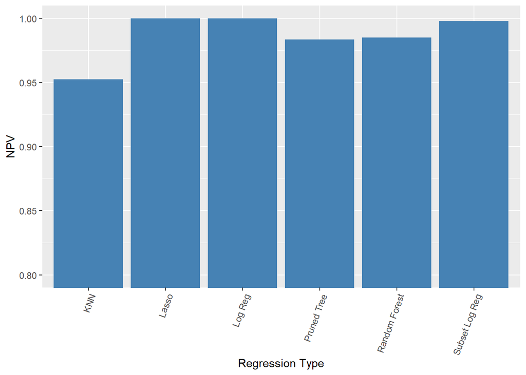

```r
ggplot(data=metric.df, aes(x=fit.names, y=npv)) +
  geom_bar(stat="identity", fill="steelblue") +
  theme(axis.text.x = element_text(angle=70, hjust=1)) +
  xlab("Regression Type") +
  ylab("NPV") +
  coord_cartesian(ylim=c(.8, 1))
```

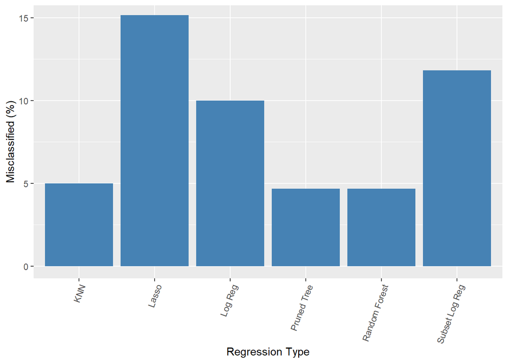

```r
ggplot(data=metric.df, aes(x=fit.names, y=misclassified)) +
  geom_bar(stat="identity", fill="steelblue") +
  theme(axis.text.x = element_text(angle=70, hjust=1)) +
  xlab("Regression Type") +
  ylab("Misclassified (%)") +
  coord_cartesian(ylim=c(0, 15))
```

Imporant metrics for correclty finding and classifying intrusions: sensitivty and NPV

Full Logistic Regression Medium Accuracy Good: High Sensitivity, High NPV, low misclassification %

Best Subset Logistic Regression Medium Acuracy Good: High sensitivity, high NPV Bad: High misclassification %

Lasso Good: High sensitivty, high NPV Bad: Low accuracy, high misclassification %

Random Forest Medium sensitity, medium NPV Good: High accuracy, low misclassificaiton %

KNN Good: High accuracy, low misclassificaiton % Bad: Very low sensitivity, low NPV

Compare the ROC graphs Note: KNN does not have probabilities associated with it, so it is not included in the ROC graph

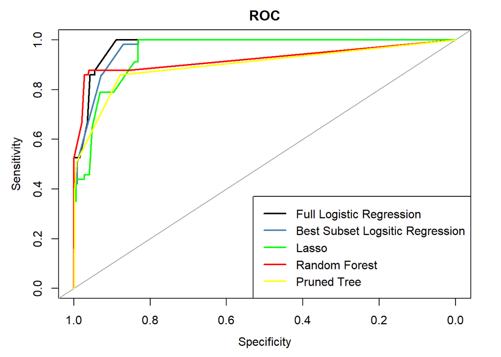

```r
plot.roc(glm.roc, main="ROC", percent=TRUE, asp=NA)
plot.roc(glm.bestroc, add=TRUE, col="steelblue",percent=TRUE, main="ROC", asp=NA)
plot.roc(lasso.roc, add=TRUE, col="green",percent=TRUE, main="ROC", asp=NA)
plot.roc(rf.roc, add=TRUE, col="red",percent=TRUE, main="ROC", asp=NA)
plot.roc(prune.roc, add=TRUE, col="yellow",percent=TRUE, main="ROC", asp=NA)
legend("bottomright", legend=c("Full Logistic Regression", "Best Subset Logsitic Regression", "Lasso", "Random Forest", "Pruned Tree"), col=c("black", "steelblue", "green", "red", "yellow"), lwd=2)
```

The full logistic regression model, best subset regression, and lasso all reach 1.0 sensitivity, but the full logsitic regression model is able to do it with minimal loss to specificity. The Random Forest increases in sensitivity with the elast decrease in specificity until a point, then the gains in sensitivty level out, and specificty starts decreasing rapidly. The pruned tree does not do very well.

Analysis of Methods

To evaluate each model’s ability to detect network intrusions, it is important to have high sensitivity and high negative predicted value. Sensitivity is the proportion of network intrusions that are correctly identified, and NPV is the proportion of events classified as not network intrusions that were in fact not network intrusions.

From the bar graphs, it can be seen that KNN and random forests have some of the highest accuracies and lowest misclassification rates out of any model. But KNN has a low NPV compared to the other models, and a very low relative sensitivity. With a sensitivity of just above 0.5, it only detects roughly half of the network intrusions in the testing data.

The ROC curve shows that the Random Forest model can increase it’s sensitivity with little loss to specificity, up to a sensitivity level of about 0.85. At this level, the specificity is almost at 1. If specificity and sensitivity were equally important, this would be the model to choose. But the ROC shows the random forest model can’t do better than a sensitivity level of 0.85, and trying to increase this metric more leads to drastic decreases in the specificity.

The lasso, full logistic regression, and subset logistic regression all are able to reach a sensitivity of 1. That is, all the models were able to correctly identify all of the network intrusions in the testing data. The NPV of the lasso and full logistic regression was 1, while the NPV of the subset logistic regression was close, at 0.998.

Given the very high sensitivity and NPV, the relatively high accuracy, and the low misclassification rate, we recommend using the full logistic model with a cutoff probability of 12.8% to find network intrusions.

If the company finds that too many normal connections are being misclassified as intrusions, we recommend switching to a random forest with a cutoff of 15.4%. This will decrease the sensitivity but increase the specificity.

One possible problem with the logistic regression model is predicting an intrusion if a log does not have a value for all of the predictors.

In conclusion, we have observed that the following variables src_bytes, service, flag, logged_in, and dst_bytes are the discerning variables that exert some degree of association on recognizing intrusions. We are confident that our models can detect intrusions in the system. New log files can be run using the full logistic regression model, glm.allfit, or the random forest model, traffic.rf.